# Using phylogenetic trees in R

# Phylogenetic Analysis in R with `ape` and `treeio`

Phylogenetic trees are key to understanding evolutionary relationships. In R, the `ape` and `treeio` packages provide tools to import, manipulate, and visualize phylogenetic trees.

These packages can be used to:

- Load trees from Newick/Nexus formats
- Create and manipulate trees (root, prune, extract clades)
- Visualize trees with base ape (`plot.phylo`) and `ggtree`
- Annotate trees with metadata and heatmaps

## Packages installation

```r
if (!requireNamespace("BiocManager", quietly = TRUE))
  install.packages("BiocManager")
if (!requireNamespace("ape", quietly = TRUE))
  install.packages("ape", update = FALSE)
if (!requireNamespace("treeio", quietly = TRUE))
  BiocManager::install("treeio", update = FALSE)
if (!requireNamespace("ggtree", quietly = TRUE))
  BiocManager::install("ggtree", update = FALSE)
if (!requireNamespace("phangorn", quietly = TRUE))
  install.packages("phangorn", update = FALSE)
```

## Load packages

```r
library(ape)
library(phangorn)
library(treeio)
library(ggtree)
library(dplyr)
library(tidyr)
library(tibble)
```

# Section 1: ape basics

## `ape` package

`ape` (Analysis of Phylogenetics and Evolution) stores trees as `phylo` objects and provides:

- `read.tree()` / `write.tree()` — Newick I/O
- `rtree()` — random tree generation
- `root()`, `drop.tip()`, `ladderize()` — tree manipulation
- `plot.phylo()` — base R tree visualization

## Functions to read and write trees

`read.tree()` reads Newick format: `((A:0.1,B:0.2):0.3,C:0.4);`

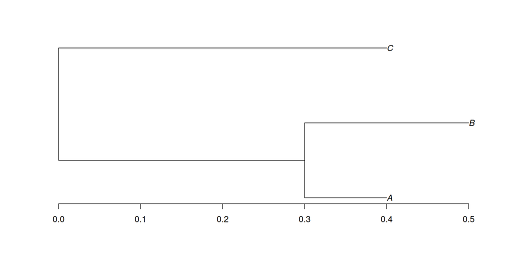

```r
newick_tree <- "((A:0.1,B:0.2):0.3,C:0.4);"
tree <- read.tree(text = newick_tree)
plot(tree)
axis(1)
```

## Plotting trees with `ape`

`plot()` on a `phylo` object calls `plot.phylo()`.

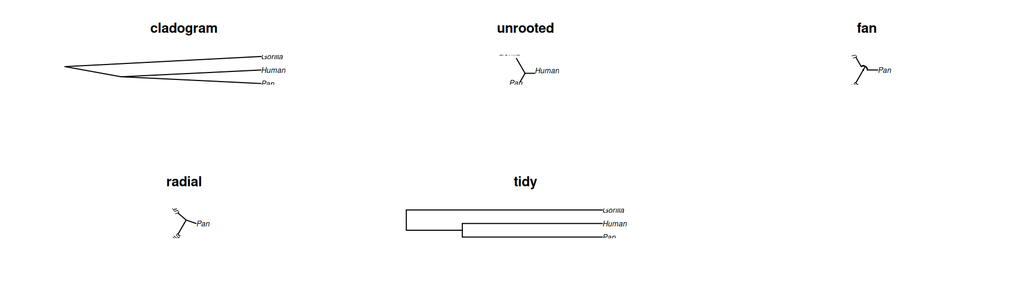

```r
tr <- read.tree(text = "((Pan:5,Human:5):2,Gorilla:7);")
par(mfrow = c(2, 3))
plot(tr, type = "cladogram", main = "cladogram")
plot(tr, type = "unrooted",  main = "unrooted")
plot(tr, type = "fan",       main = "fan")
plot(tr, type = "radial",    main = "radial")
plot(tr, type = "tidy",      main = "tidy")
```

## Loading tree from file

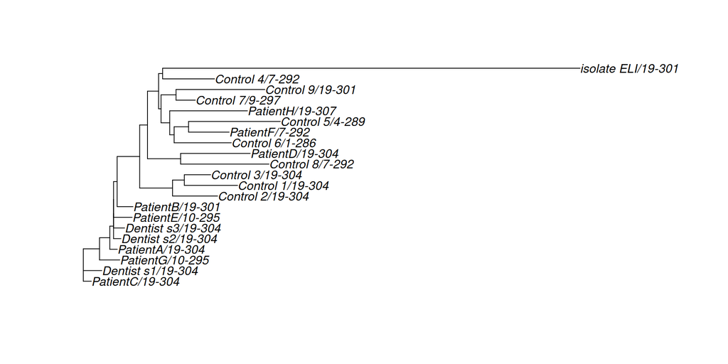

```r
tr_dentist <- read.tree("../data/phylogenetics/HIV_dentist.nhx")
plot(tr_dentist)
```

## Properties of `phylo` class

```r
tr <- rtree(5)   # random tree with 5 tips
print(tr)
```

```
Phylogenetic tree with 5 tips and 4 internal nodes.

Tip labels:
  t2, t3, t4, t5, t1

Rooted; includes branch lengths.
```

```r
class(tr)
```

```
[1] "phylo"
```

```r
names(tr)
```

```
[1] "edge"        "tip.label"   "Nnode"       "edge.length"
```

## Properties of `phylo` class — `edge`

- `edge`: matrix with two columns; each row is one branch (parent → child)

```r
plot.phylo(tr, type = "tidy", show.tip.label = TRUE, cex = 1)
```

```r
print(tr$edge)
```

```
     [,1] [,2]
[1,]    6    7
[2,]    7    1
[3,]    7    2
[4,]    6    8
[5,]    8    9
[6,]    9    3
[7,]    9    4
[8,]    8    5
```

[figure not shown]

## Properties of `phylo` class — `tip.label` and `edge.length`

```r
print(tr$tip.label)
```

```
[1] "t2" "t3" "t4" "t5" "t1"
```

```r
print(tr$edge.length)
```

```
[1] 0.1423927 0.8016808 0.7275904 0.2609529 0.1174972 0.3786687 0.8834886
[8] 0.8146820
```

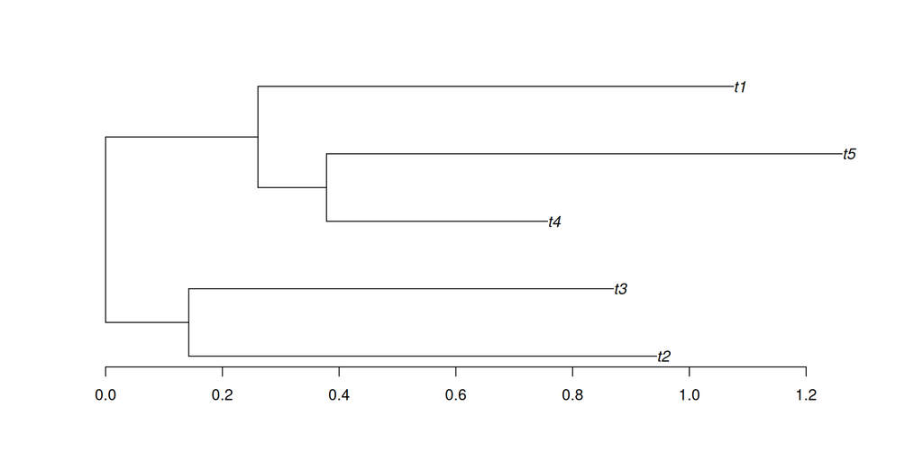

```r
plot(tr, type = "tidy", show.tip.label = TRUE, cex = 1)
axis(1)
```

## Properties of `phylo` class — numbered diagram

```r
tr$tip.label  <- as.character(1:Ntip(tr))
tr$node.label <- as.character((Ntip(tr) + 1):(Ntip(tr) + Nnode(tr)))
cat("Edge matrix:\n")
```

```
Edge matrix:
```

```r
print(tr$edge)
```

```
     [,1] [,2]
[1,]    6    7
[2,]    7    1
[3,]    7    2
[4,]    6    8
[5,]    8    9
[6,]    9    3
[7,]    9    4
[8,]    8    5
```

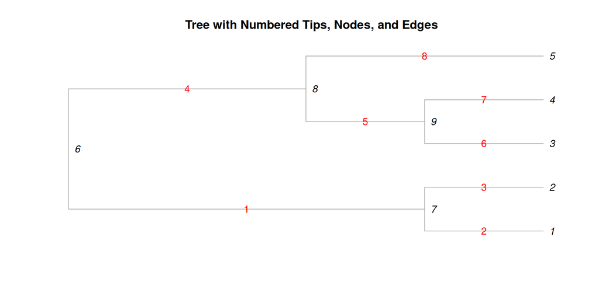

```r
plot(tr, type = "phylogram", use.edge.length = FALSE,
     show.tip.label = TRUE, show.node.label = TRUE,
     label.offset = 0.05, cex = 1, edge.color = "darkgray",
     main = "Tree with Numbered Tips, Nodes, and Edges")
edgelabels(text = seq_len(nrow(tr$edge)),
           frame = "none", adj = 0.5, cex = 1, col = "red")
```

# Section 2: Tree manipulation

## Manipulating trees

- `is.rooted()` — check if rooted
- `unroot()` — remove the root
- `root()` — re-root at a tip or node

```r
tips <- c("Outgroup", paste0("Species", 1:5))
set.seed(123)
unrooted_tree <- rtree(6, tip.label = tips, rooted = FALSE)
is.rooted(unrooted_tree)
```

```
[1] FALSE
```

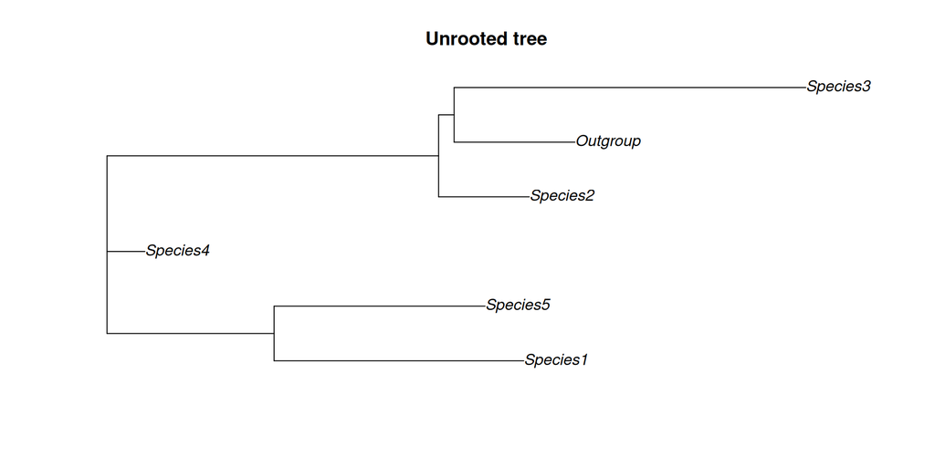

```r
plot(unrooted_tree, main = "Unrooted tree")
```

## Rooting a tree

```r
rooted_tree <- root(unrooted_tree, outgroup = "Outgroup", resolve.root = TRUE)
is.rooted(rooted_tree)
```

```
[1] TRUE
```

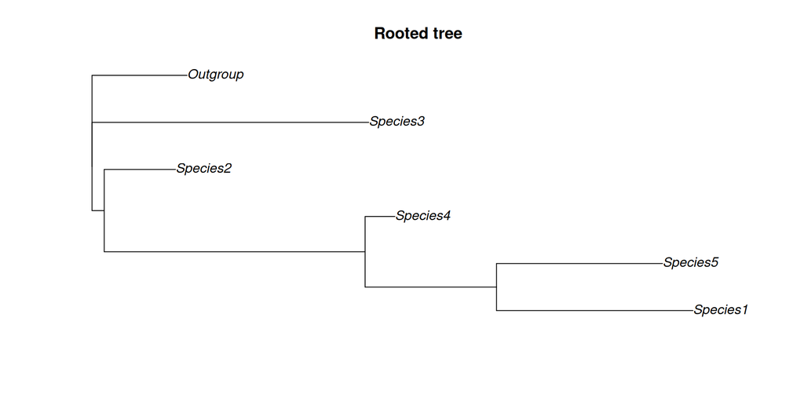

```r
plot(rooted_tree, main = "Rooted tree")
```

## Rooting a tree

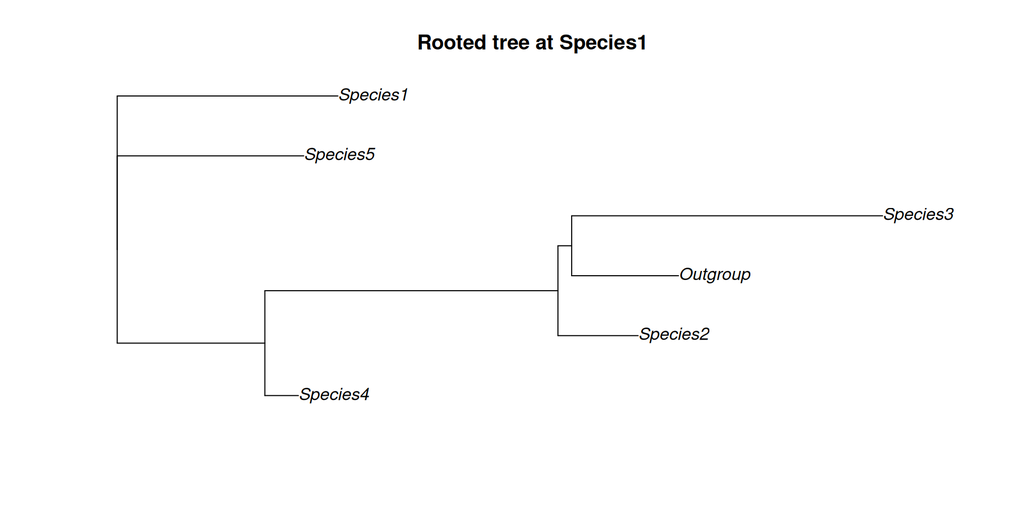

```r
rooted_tree <- root(unrooted_tree, outgroup = "Species1", resolve.root = TRUE)
plot(rooted_tree, main = "Rooted tree at Species1")
```

## Ladderizing a tree

- Reorders branches so the tree has a tidy ladder-like appearance.
- Evolutionary relationships are unchanged; only the visual order of tips changes.

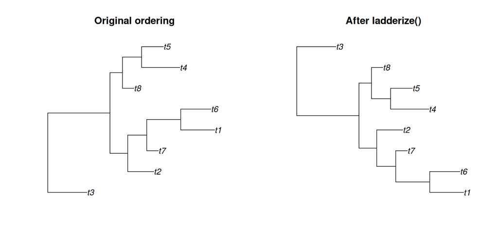

```r
tree2 <- rtree(8)
par(mfrow = c(1, 2))
plot(tree2,            main = "Original ordering")
plot(ladderize(tree2), main = "After ladderize()")
```

## Pruning and dropping tips

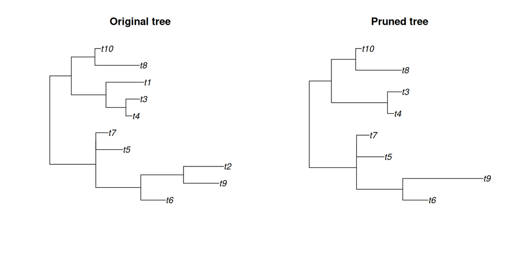

```r
tr <- rtree(10)
par(mfrow = c(1, 2))
plot(tr, main = "Original tree")
pruned_tree <- drop.tip(tr, c("t1", "t2"))
plot(pruned_tree, main = "Pruned tree")
```

# Section 3: Clade extraction

## Extracting clades

- `getMRCA(tree, tips)` — most recent common ancestor node for a set of tips
- `extract.clade(tree, node)` — subtree descended from a node
- `nodepath(tree, from, to)` — sequence of nodes between two nodes

## Understanding node numbering

- Tips: numbered **1 to N**
- Internal nodes: numbered **(N+1) to (N + Nnode)**

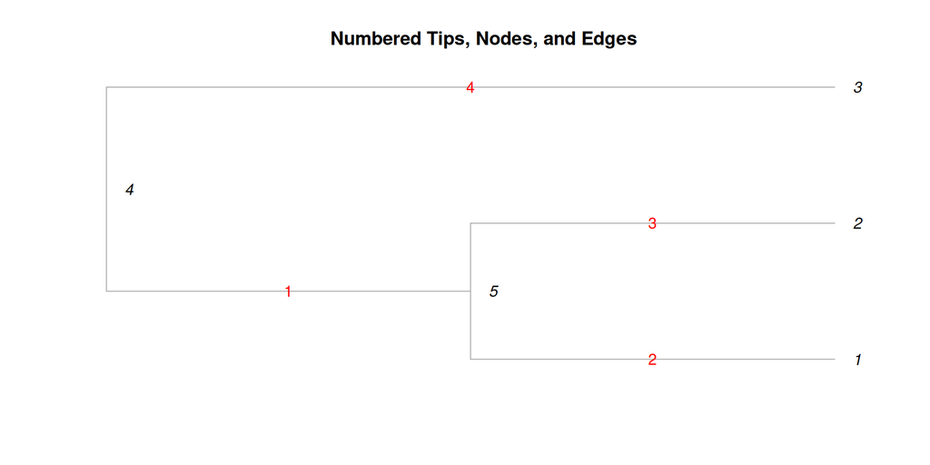

```r
set.seed(123)
tr <- rtree(3)
tr$tip.label  <- as.character(1:Ntip(tr))
tr$node.label <- as.character((Ntip(tr) + 1):(Ntip(tr) + Nnode(tr)))
plot(tr, type = "phylogram", use.edge.length = FALSE,
     show.tip.label = TRUE, show.node.label = TRUE,
     label.offset = 0.05, cex = 1, edge.color = "darkgray",
     main = "Numbered Tips, Nodes, and Edges")
edgelabels(text = seq_len(nrow(tr$edge)),
           frame = "none", adj = 0.5, cex = 1, col = "red")
```

## Getting MRCA

```r
mrca_node <- getMRCA(tr, c("1", "2"))
print(mrca_node)
```

```
[1] 5
```

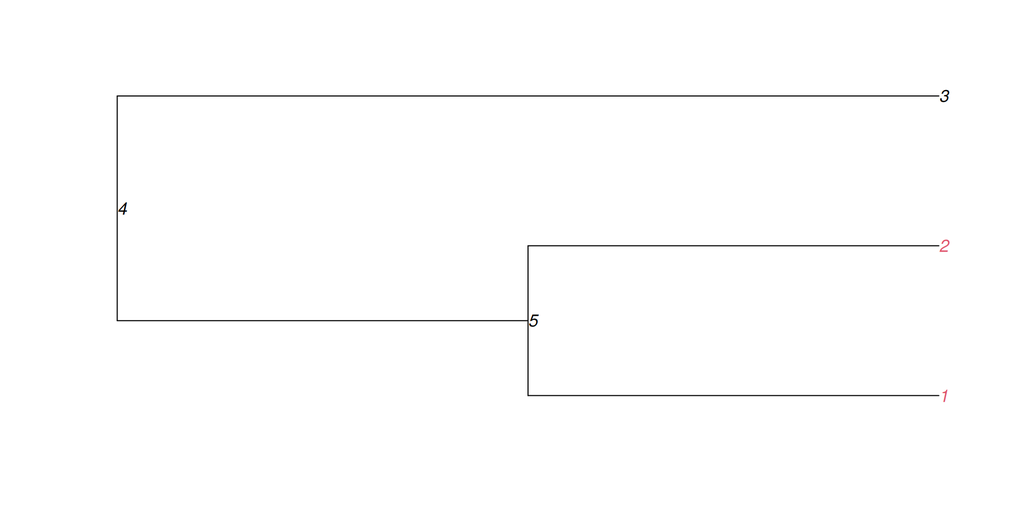

```r
plot(tr, show.tip.label = TRUE, show.node.label = TRUE,
     type = "phylogram", use.edge.length = FALSE,
     tip.color = c(2, 2, 1))
```

## Extracting clades descended from MRCA

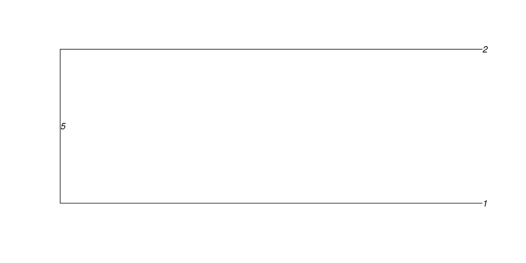

```r
clade <- extract.clade(tr, mrca_node)
plot(clade, show.tip.label = TRUE, show.node.label = TRUE,
     type = "phylogram", use.edge.length = FALSE)
```

## Extracting clades descended from MRCA

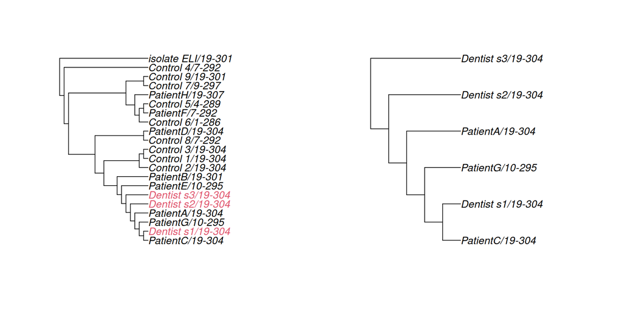

```r
tr_dentist_rooted <- root(
  tr_dentist,
  outgroup     = which(tr_dentist$tip.label %in% "isolate_ELI/19-301"),
  resolve.root = TRUE
)
MRCA_node        <- getMRCA(tr_dentist_rooted, grep("Dentist", tr_dentist_rooted$tip.label))
tr_dentist_clade <- extract.clade(tr_dentist_rooted, MRCA_node)
par(mfrow = c(1, 2))
color <- grepl("Dentist", tr_dentist_rooted$tip.label) + 1
plot(tr_dentist_rooted, type = "phylogram", use.edge.length = FALSE, tip.color = color)
plot(tr_dentist_clade,  type = "phylogram", use.edge.length = FALSE)
```

# Section 4: Base ape plotting

## Basic plotting with `plot.phylo`

The simplest call: `plot(my_tree)`

Key arguments: - `type`: `"phylogram"`, `"cladogram"`, `"fan"`, `"unrooted"`, `"radial"` - `edge.color`, `edge.width`, `tip.color`, `cex` - `use.edge.length`: `FALSE` draws as cladogram regardless of type

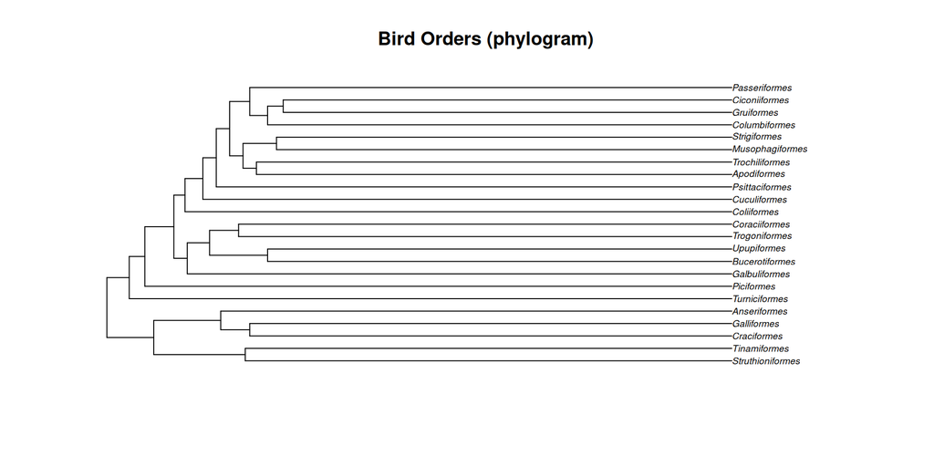

```r
data(bird.orders)
plot(bird.orders, cex = 0.6, main = "Bird Orders (phylogram)")
```

## Basic plotting with `plot.phylo`

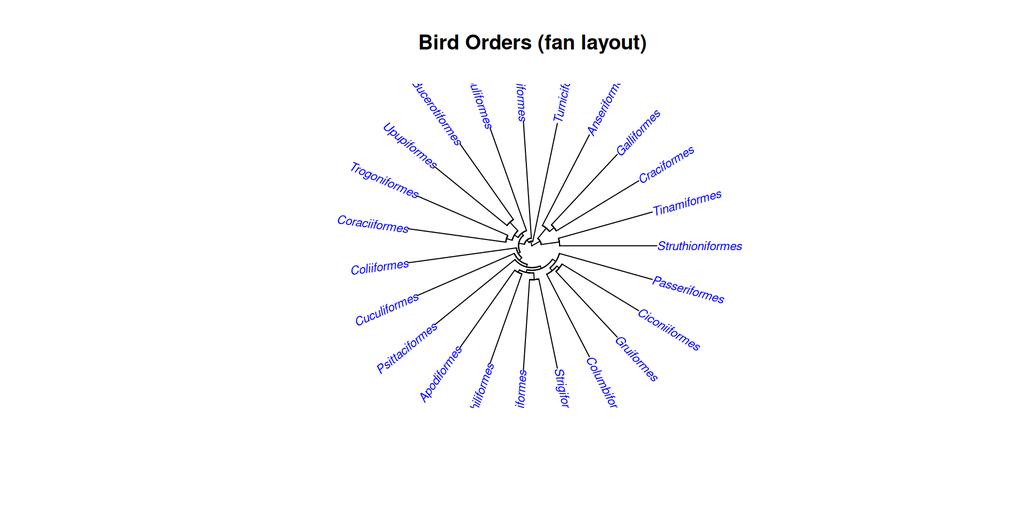

```r
plot(bird.orders, type = "fan", cex = 0.7, tip.color = "blue",
     main = "Bird Orders (fan layout)")
```

## Basic plotting with `plot.phylo`

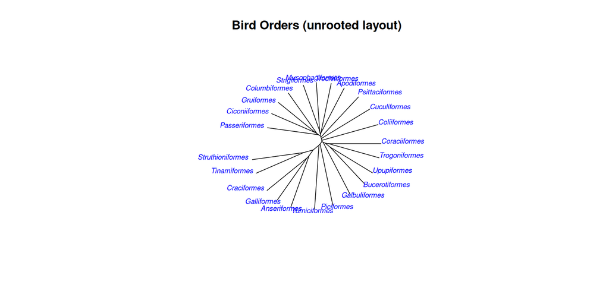

```r
plot(bird.orders, type = "unrooted", cex = 0.7, tip.color = "blue",
     main = "Bird Orders (unrooted layout)")
```

## Adding annotations in base plots

- `tiplabels()` — symbols or text next to tips
- `nodelabels()` — labels at internal nodes (e.g. bootstrap values)
- `edgelabels()` — text on branches

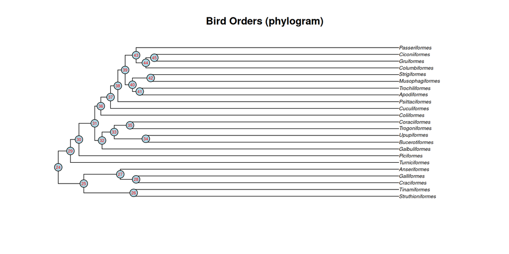

```r
plot(bird.orders, cex = 0.6, main = "Bird Orders (phylogram)")
nodelabels(frame = "circle", cex = 0.5, col = "red")
```

## Setting colors for tip labels

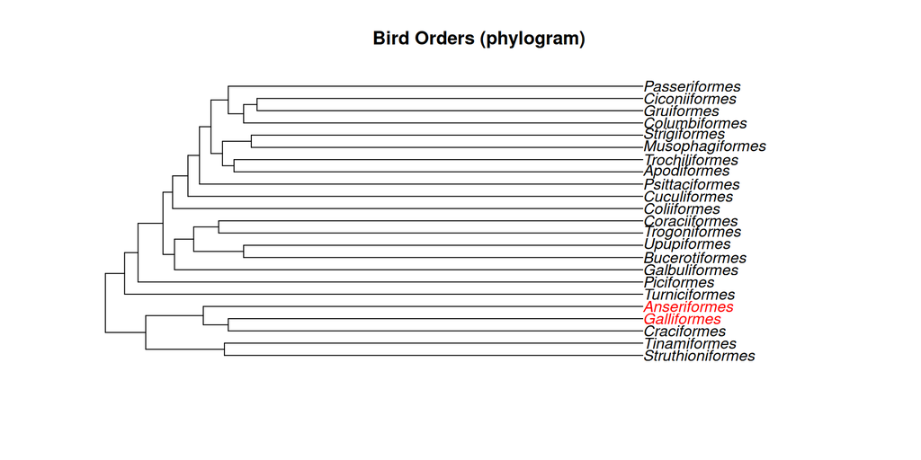

```r
tip_colors <- ifelse(
  bird.orders$tip.label %in% c("Anseriformes", "Galliformes"),
  "red", "black"
)
plot(bird.orders, cex = 1, main = "Bird Orders (phylogram)", tip.color = tip_colors)
```

## Setting colors for tip labels

Set color for clade shared by `Anseriformes` and `Struthioniformes`:

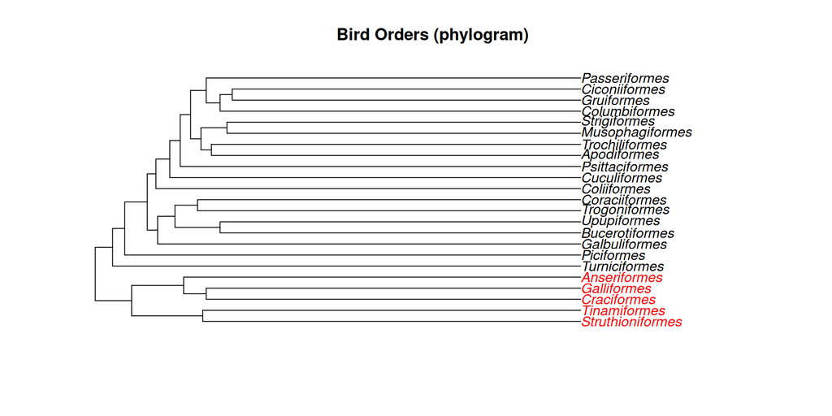

```r
mrca_node        <- getMRCA(bird.orders, c("Anseriformes", "Struthioniformes"))
clade            <- extract.clade(bird.orders, mrca_node)
tip_labels_clade <- clade$tip.label
tip_colors       <- ifelse(bird.orders$tip.label %in% tip_labels_clade, "red", "black")
plot(bird.orders, cex = 1, main = "Bird Orders (phylogram)", tip.color = tip_colors)
```

> 📝 **Task 1** — Plot bird.orders as `"fan"`. Color the MRCA clade of `"Passeriformes"` and `"Piciformes"` blue, all others black.

# Section 5: ggtree

## Visualizing trees with `ggtree`

`ggtree` extends ggplot2 for phylogenetic trees — every ggplot2 layer and theme applies.

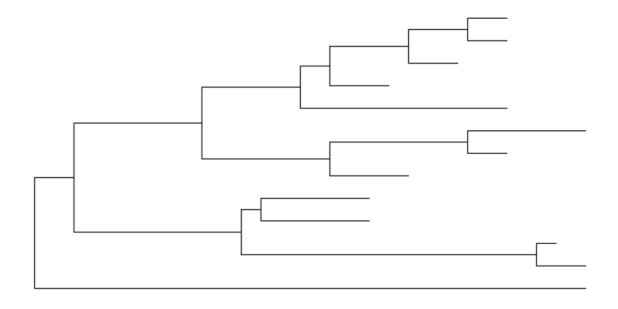

```r
nwk  <- system.file("extdata", "sample.nwk", package = "treeio")
tree <- read.tree(nwk)
ggplot(tree, aes(x, y)) + geom_tree() + theme_tree()
```

## Visualizing trees with `ggtree`

`ggtree()` is the shortcut for the above:

```r
ggtree(tree, color = "firebrick", size = 2, linetype = "dotted")
```

[figure not shown]